# Woods_Moneyball_2

# TARGET WINS MODEL

```r
summary(lr_md5 <- lm(TARGET_WINS ~ . - X - INDEX, data = df))
```

```
Call:
lm(formula = TARGET_WINS ~ . - X - INDEX, data = df)

Residuals:
    Min      1Q  Median      3Q     Max
-51.610  -8.874   0.134   8.583  57.706

Coefficients:
                          Estimate Std. Error t value Pr(>|t|)
(Intercept)              1.321e+01  5.405e+00   2.443 0.014628 *
TEAM_BATTING_H           4.478e-02  4.048e-03  11.062  < 2e-16 ***
TEAM_BATTING_2B         -2.061e-02  9.399e-03  -2.193 0.028395 *
TEAM_BATTING_3B          7.346e-02  1.712e-02   4.291 1.86e-05 ***
TEAM_BATTING_HR          4.616e-02  2.817e-02   1.639 0.101385
TEAM_BATTING_BB          7.772e-03  6.274e-03   1.239 0.215512
TEAM_BATTING_SO         -8.855e-03  2.699e-03  -3.281 0.001050 **
TEAM_BASERUN_SB          3.611e-02  4.389e-03   8.228 3.19e-16 ***
TEAM_PITCHING_H         -5.326e-04  4.490e-04  -1.186 0.235648
TEAM_PITCHING_HR         9.590e-03  2.505e-02   0.383 0.701910
TEAM_PITCHING_BB        -3.524e-03  4.625e-03  -0.762 0.446161
TEAM_PITCHING_SO         4.318e-03  1.042e-03   4.143 3.55e-05 ***
TEAM_FIELDING_E         -2.194e-02  2.463e-03  -8.909  < 2e-16 ***
trunc_team_batting_1122 -3.221e+01  9.297e+00  -3.464 0.000541 ***
trunc_team_batting_2333  8.271e+00  7.208e+00   1.148 0.251289
---
Signif. codes:  0 ‘***’ 0.001 ‘**’ 0.01 ‘*’ 0.05 ‘.’ 0.1 ‘ ’ 1

Residual standard error: 13.25 on 2260 degrees of freedom
Multiple R-squared:  0.2887,    Adjusted R-squared:  0.2843
F-statistic: 65.53 on 14 and 2260 DF,  p-value: < 2.2e-16
```

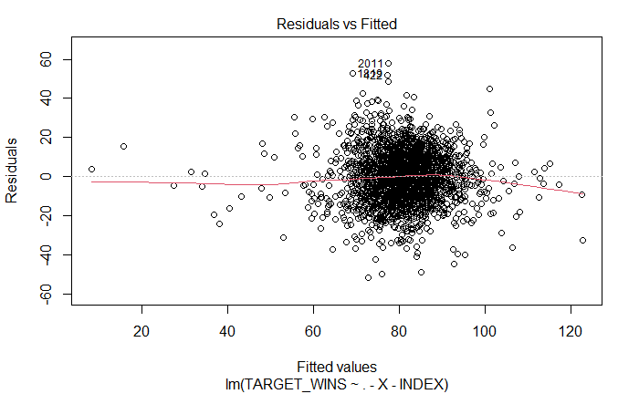

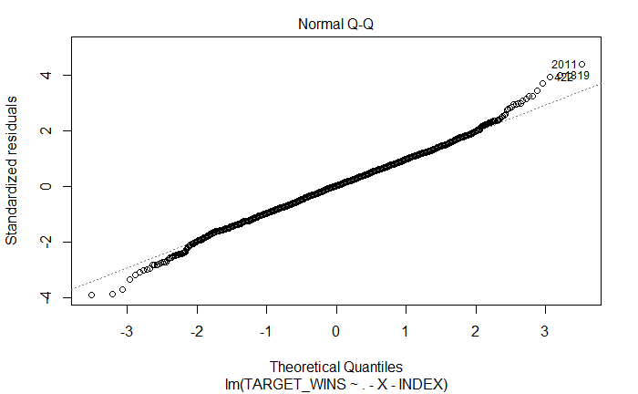

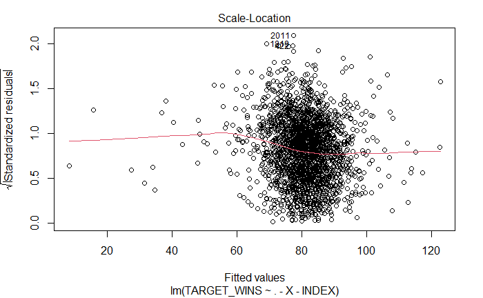

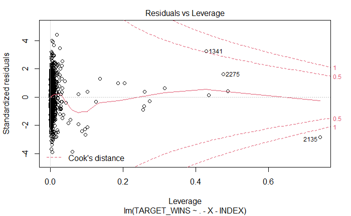

```r
plot(lr_md5)
```

```r
NA
NA
```

Now let’s log transform TARGET_WINS and compare the models:

```r
summary(lr_md6 <- lm(log(TARGET_WINS) ~ . - X - INDEX, data = df))
```

```
Call:
lm(formula = log(TARGET_WINS) ~ . - X - INDEX, data = df)

Residuals:
     Min       1Q   Median       3Q      Max
-1.20211 -0.10638  0.01387  0.11561  0.60719

Coefficients:
                          Estimate Std. Error t value Pr(>|t|)
(Intercept)              3.421e+00  7.341e-02  46.606  < 2e-16 ***
TEAM_BATTING_H           6.644e-04  5.498e-05  12.084  < 2e-16 ***
TEAM_BATTING_2B         -3.274e-04  1.277e-04  -2.564 0.010399 *
TEAM_BATTING_3B          9.923e-04  2.325e-04   4.267 2.06e-05 ***
TEAM_BATTING_HR          3.219e-04  3.825e-04   0.842 0.400092
TEAM_BATTING_BB          4.203e-05  8.520e-05   0.493 0.621829
TEAM_BATTING_SO         -9.998e-05  3.666e-05  -2.728 0.006430 **
TEAM_BASERUN_SB          4.887e-04  5.961e-05   8.198 4.04e-16 ***
TEAM_PITCHING_H         -2.040e-05  6.098e-06  -3.346 0.000832 ***
TEAM_PITCHING_HR         2.982e-04  3.402e-04   0.876 0.380932
TEAM_PITCHING_BB        -8.230e-06  6.281e-05  -0.131 0.895769
TEAM_PITCHING_SO         7.494e-05  1.415e-05   5.295 1.31e-07 ***
TEAM_FIELDING_E         -3.865e-04  3.345e-05 -11.554  < 2e-16 ***
trunc_team_batting_1122 -8.311e-01  1.263e-01  -6.582 5.75e-11 ***
trunc_team_batting_2333  1.221e-01  9.789e-02   1.247 0.212576
---
Signif. codes:  0 ‘***’ 0.001 ‘**’ 0.01 ‘*’ 0.05 ‘.’ 0.1 ‘ ’ 1

Residual standard error: 0.18 on 2260 degrees of freedom
Multiple R-squared:  0.337, Adjusted R-squared:  0.3329
F-statistic: 82.06 on 14 and 2260 DF,  p-value: < 2.2e-16
```

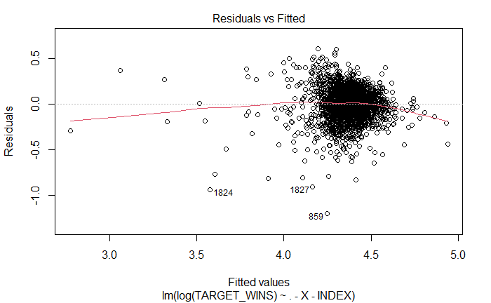

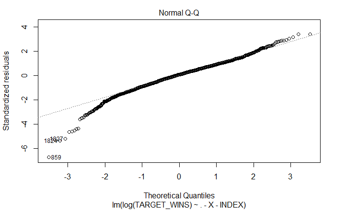

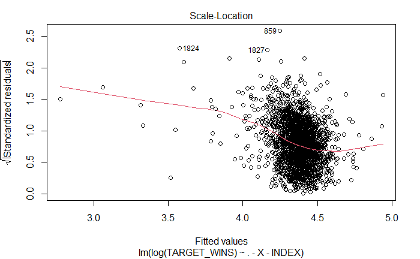

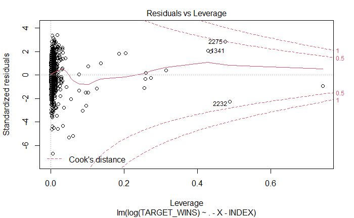

```r
plot(lr_md6)
```

```r
NA
NA
```

Log transforming TARGET_WINS increased adjusted R Squared by .0486.

VIF for each model:

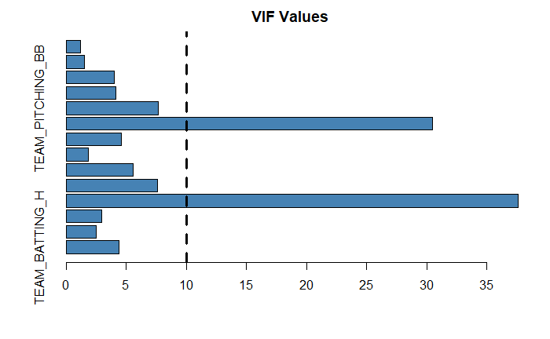

```r
library(car)

vif_values <- vif(lr_md6)

#create horizontal bar chart to display each VIF value
barplot(vif_values, main = "VIF Values", horiz = TRUE, col = "steelblue")

#add vertical line at 5
abline(v = 10, lwd = 3, lty = 2)
```

```r
vif_values
```

```
         TEAM_BATTING_H         TEAM_BATTING_2B         TEAM_BATTING_3B         TEAM_BATTING_HR         TEAM_BATTING_BB
               4.408017                2.501333                2.959366               37.632821                7.616297
        TEAM_BATTING_SO         TEAM_BASERUN_SB         TEAM_PITCHING_H        TEAM_PITCHING_HR        TEAM_PITCHING_BB
               5.544767                1.810944                4.598949               30.510765                7.631486
       TEAM_PITCHING_SO         TEAM_FIELDING_E trunc_team_batting_1122 trunc_team_batting_2333
               4.106503                3.984186                1.474668                1.181368
```

Team pitching HR and team batting HR both have VIFS above 30, so I am going to drop TEAM_BATTING_HR and re run the model.

```r
summary(lr_md7 <- lm(log(TARGET_WINS) ~ . - X - INDEX - TEAM_BATTING_HR, data = df))
```

```
Call:
lm(formula = log(TARGET_WINS) ~ . - X - INDEX - TEAM_BATTING_HR,
    data = df)

Residuals:
     Min       1Q   Median       3Q      Max
-1.20158 -0.10707  0.01413  0.11457  0.60596

Coefficients:
                          Estimate Std. Error t value Pr(>|t|)
(Intercept)              3.415e+00  7.306e-02  46.746  < 2e-16 ***
TEAM_BATTING_H           6.676e-04  5.485e-05  12.172  < 2e-16 ***
TEAM_BATTING_2B         -3.260e-04  1.276e-04  -2.554  0.01070 *
TEAM_BATTING_3B          9.475e-04  2.263e-04   4.186 2.95e-05 ***
TEAM_BATTING_BB          7.341e-05  7.661e-05   0.958  0.33800
TEAM_BATTING_SO         -9.778e-05  3.656e-05  -2.674  0.00754 **
TEAM_BASERUN_SB          4.871e-04  5.957e-05   8.176 4.83e-16 ***
TEAM_PITCHING_H         -1.987e-05  6.064e-06  -3.277  0.00107 **
TEAM_PITCHING_HR         5.670e-04  1.172e-04   4.836 1.41e-06 ***
TEAM_PITCHING_BB        -3.145e-05  5.643e-05  -0.557  0.57739
TEAM_PITCHING_SO         7.764e-05  1.378e-05   5.633 1.99e-08 ***
TEAM_FIELDING_E         -3.880e-04  3.340e-05 -11.617  < 2e-16 ***
trunc_team_batting_1122 -8.296e-01  1.262e-01  -6.572 6.16e-11 ***
trunc_team_batting_2333  1.072e-01  9.628e-02   1.113  0.26571
---
Signif. codes:  0 ‘***’ 0.001 ‘**’ 0.01 ‘*’ 0.05 ‘.’ 0.1 ‘ ’ 1

Residual standard error: 0.18 on 2261 degrees of freedom
Multiple R-squared:  0.3368,    Adjusted R-squared:  0.333
F-statistic: 88.33 on 13 and 2261 DF,  p-value: < 2.2e-16
```

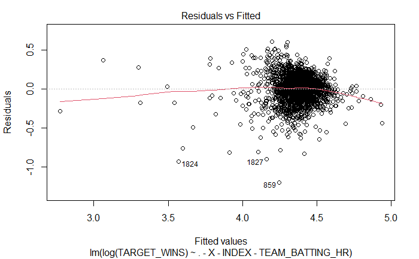

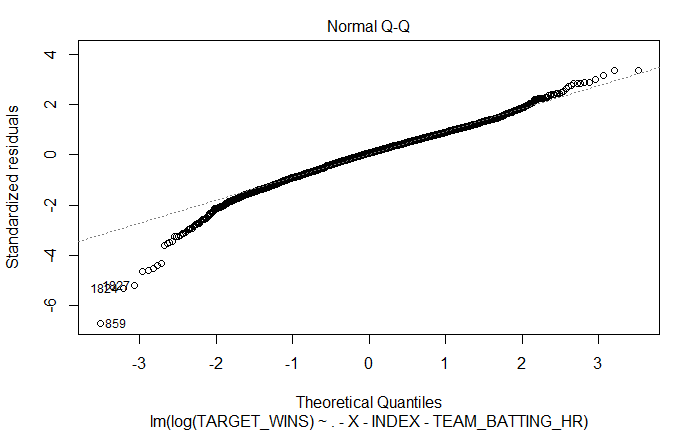

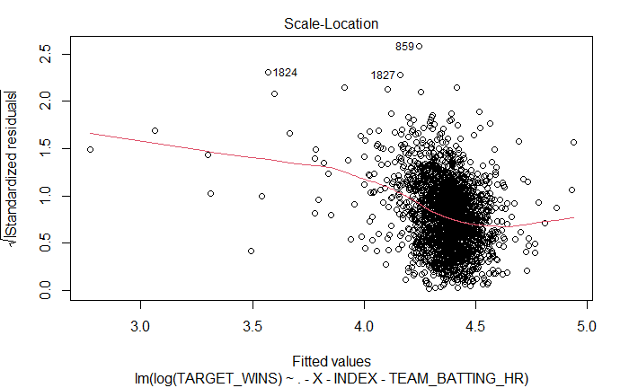

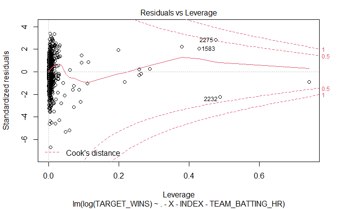

```r
plot(lr_md7)
```

```r
vif(lr_md7)
```

```
         TEAM_BATTING_H         TEAM_BATTING_2B         TEAM_BATTING_3B         TEAM_BATTING_BB         TEAM_BATTING_SO
               4.386928                2.500952                2.804292                6.157697                5.516506
        TEAM_BASERUN_SB         TEAM_PITCHING_H        TEAM_PITCHING_HR        TEAM_PITCHING_BB        TEAM_PITCHING_SO
               1.809127                4.548798                3.623467                6.159626                3.895306
        TEAM_FIELDING_E trunc_team_batting_1122 trunc_team_batting_2333
               3.972519                1.474402                1.142845
```

Let’s try transformations to predictor variables too:

First, lets plot each continuous distribution:

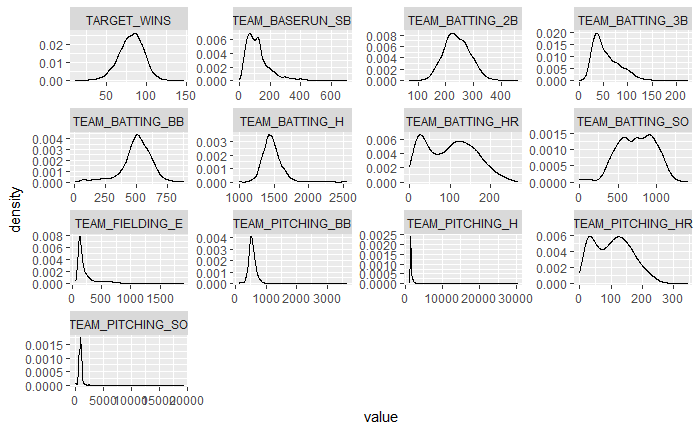

```r
ggplot(gather(df[, 3:15], variable, value), aes(x=value)) + geom_density() +
  facet_wrap(~variable, scales = "free")
```

```r
NA
NA
```

Following, this general guide, I will apply transformations:

square-root for moderate skew: sqrt(x) for positively skewed data, sqrt(max(x+1) - x) for negatively skewed data

log for greater skew: log10(x) for positively skewed data, log10(max(x+1) - x) for negatively skewed data

inverse for severe skew: 1/x for positively skewed data 1/(max(x+1) - x) for negatively skewed data

```r
summary(lr_md8 <- lm(log(TARGET_WINS) ~ TEAM_BATTING_H + TEAM_BATTING_2B + TEAM_BATTING_3B + TEAM_BATTING_BB + TEAM_BATTING_SO + sqrt(TEAM_BASERUN_SB) + TEAM_PITCHING_H + TEAM_PITCHING_HR + sqrt(TEAM_PITCHING_BB) + TEAM_PITCHING_SO + sqrt(TEAM_FIELDING_E) + trunc_team_batting_1122 + trunc_team_batting_2333, data = df))
```

```
Call:
lm(formula = log(TARGET_WINS) ~ TEAM_BATTING_H + TEAM_BATTING_2B +
    TEAM_BATTING_3B + TEAM_BATTING_BB + TEAM_BATTING_SO + sqrt(TEAM_BASERUN_SB) +
    TEAM_PITCHING_H + TEAM_PITCHING_HR + sqrt(TEAM_PITCHING_BB) +
    TEAM_PITCHING_SO + sqrt(TEAM_FIELDING_E) + trunc_team_batting_1122 +
    trunc_team_batting_2333, data = df)

Residuals:
     Min       1Q   Median       3Q      Max
-1.19934 -0.10522  0.01143  0.11380  0.63294

Coefficients:
                          Estimate Std. Error t value Pr(>|t|)
(Intercept)              3.573e+00  8.503e-02  42.021  < 2e-16 ***
TEAM_BATTING_H           6.515e-04  5.477e-05  11.895  < 2e-16 ***
TEAM_BATTING_2B         -3.680e-04  1.273e-04  -2.890 0.003885 **
TEAM_BATTING_3B          1.218e-03  2.293e-04   5.312 1.19e-07 ***
TEAM_BATTING_BB          1.845e-04  9.117e-05   2.024 0.043094 *
TEAM_BATTING_SO         -1.472e-04  3.596e-05  -4.092 4.43e-05 ***
sqrt(TEAM_BASERUN_SB)    1.424e-02  1.484e-03   9.596  < 2e-16 ***
TEAM_PITCHING_H         -2.234e-05  5.865e-06  -3.808 0.000144 ***
TEAM_PITCHING_HR         5.773e-04  1.184e-04   4.877 1.15e-06 ***
sqrt(TEAM_PITCHING_BB)  -5.391e-03  3.389e-03  -1.591 0.111762
TEAM_PITCHING_SO         9.315e-05  1.253e-05   7.432 1.51e-13 ***
sqrt(TEAM_FIELDING_E)   -1.670e-02  1.424e-03 -11.721  < 2e-16 ***
trunc_team_batting_1122 -8.699e-01  1.250e-01  -6.960 4.43e-12 ***
trunc_team_batting_2333  1.202e-01  9.604e-02   1.252 0.210802
---
Signif. codes:  0 ‘***’ 0.001 ‘**’ 0.01 ‘*’ 0.05 ‘.’ 0.1 ‘ ’ 1

Residual standard error: 0.1792 on 2261 degrees of freedom
Multiple R-squared:  0.3426,    Adjusted R-squared:  0.3388
F-statistic: 90.63 on 13 and 2261 DF,  p-value: < 2.2e-16
```

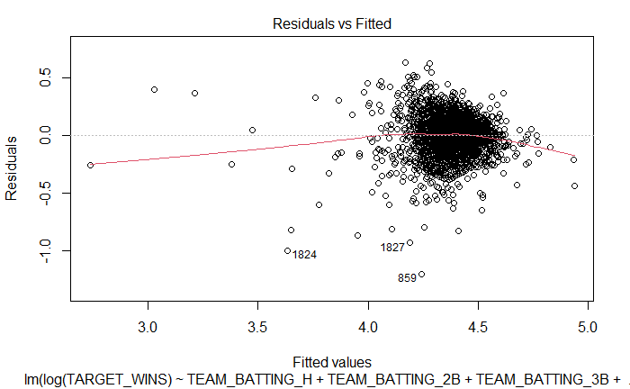

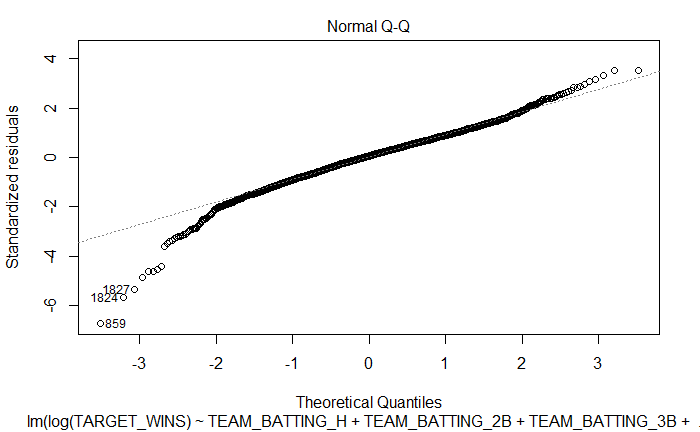

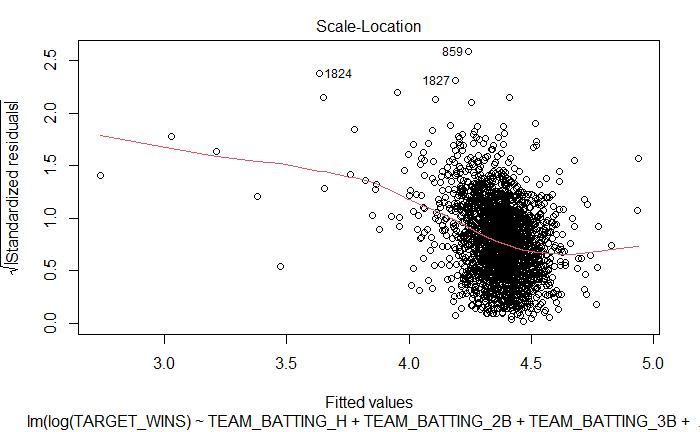

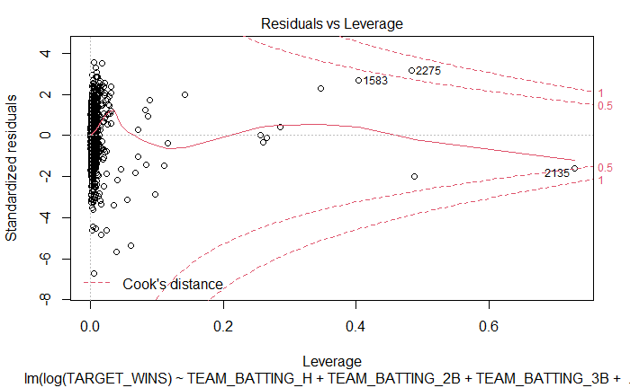

```r
plot(lr_md8)
```

```r
NA
NA
```

```r
summary(lr_md9 <- lm(log(TARGET_WINS) ~ sqrt(TEAM_BATTING_H) + TEAM_BATTING_2B + sqrt(TEAM_BATTING_3B) + TEAM_BATTING_BB + TEAM_BATTING_SO + sqrt(TEAM_BASERUN_SB) + sqrt(TEAM_PITCHING_H) + TEAM_PITCHING_HR + sqrt(TEAM_PITCHING_BB) + TEAM_PITCHING_SO + sqrt(TEAM_FIELDING_E) + trunc_team_batting_1122 + trunc_team_batting_2333, data = df))
```

```
Call:
lm(formula = log(TARGET_WINS) ~ sqrt(TEAM_BATTING_H) + TEAM_BATTING_2B +
    sqrt(TEAM_BATTING_3B) + TEAM_BATTING_BB + TEAM_BATTING_SO +
    sqrt(TEAM_BASERUN_SB) + sqrt(TEAM_PITCHING_H) + TEAM_PITCHING_HR +
    sqrt(TEAM_PITCHING_BB) + TEAM_PITCHING_SO + sqrt(TEAM_FIELDING_E) +
    trunc_team_batting_1122 + trunc_team_batting_2333, data = df)

Residuals:
     Min       1Q   Median       3Q      Max
-1.20462 -0.10573  0.01101  0.11274  0.63552

Coefficients:
                          Estimate Std. Error t value Pr(>|t|)
(Intercept)              2.570e+00  1.541e-01  16.682  < 2e-16 ***
sqrt(TEAM_BATTING_H)     5.096e-02  4.534e-03  11.240  < 2e-16 ***
TEAM_BATTING_2B         -3.648e-04  1.284e-04  -2.841  0.00454 **
sqrt(TEAM_BATTING_3B)    1.970e-02  3.655e-03   5.391 7.73e-08 ***
TEAM_BATTING_BB          2.246e-04  1.017e-04   2.208  0.02733 *
TEAM_BATTING_SO         -1.472e-04  3.625e-05  -4.061 5.05e-05 ***
sqrt(TEAM_BASERUN_SB)    1.496e-02  1.488e-03  10.052  < 2e-16 ***
sqrt(TEAM_PITCHING_H)   -2.425e-03  1.176e-03  -2.061  0.03940 *
TEAM_PITCHING_HR         6.181e-04  1.204e-04   5.134 3.08e-07 ***
sqrt(TEAM_PITCHING_BB)  -7.310e-03  3.707e-03  -1.972  0.04876 *
TEAM_PITCHING_SO         9.421e-05  1.263e-05   7.462 1.21e-13 ***
sqrt(TEAM_FIELDING_E)   -1.634e-02  1.540e-03 -10.611  < 2e-16 ***
trunc_team_batting_1122 -8.969e-01  1.276e-01  -7.029 2.75e-12 ***
trunc_team_batting_2333  1.687e-01  9.524e-02   1.772  0.07661 .
---
Signif. codes:  0 ‘***’ 0.001 ‘**’ 0.01 ‘*’ 0.05 ‘.’ 0.1 ‘ ’ 1

Residual standard error: 0.1797 on 2261 degrees of freedom
Multiple R-squared:  0.339, Adjusted R-squared:  0.3352
F-statistic: 89.19 on 13 and 2261 DF,  p-value: < 2.2e-16
```

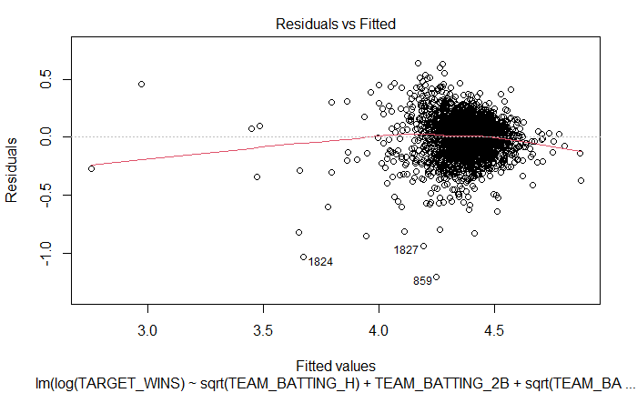

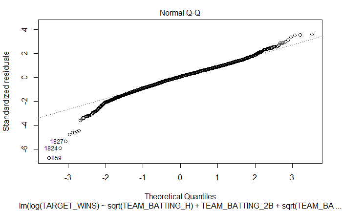

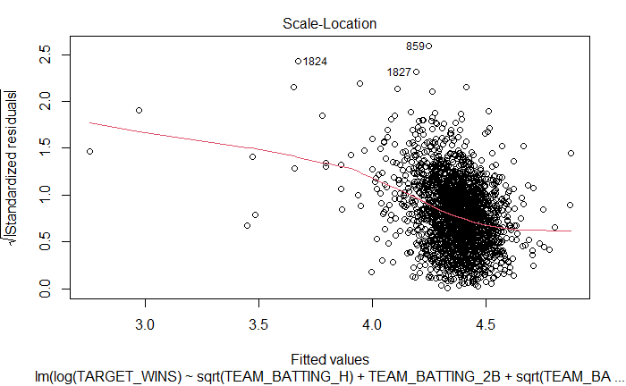

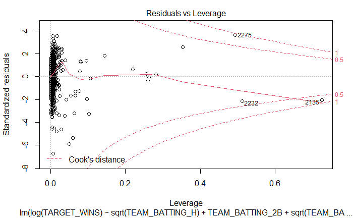

```r
plot(lr_md9)
```

Adding additional sqrt transformations reduced adjusted R squared slightly.

I am going add a log 10 transformation to lr_md8

```r
summary(lr_md10 <- lm(log10(TARGET_WINS) ~ TEAM_BATTING_H + TEAM_BATTING_2B + TEAM_BATTING_3B + TEAM_BATTING_BB + TEAM_BATTING_SO + sqrt(TEAM_BASERUN_SB) + TEAM_PITCHING_H + TEAM_PITCHING_HR + sqrt(TEAM_PITCHING_BB) + TEAM_PITCHING_SO + sqrt(TEAM_FIELDING_E) + trunc_team_batting_1122 + trunc_team_batting_2333, data = df))
```

```
Call:
lm(formula = log10(TARGET_WINS) ~ TEAM_BATTING_H + TEAM_BATTING_2B +
    TEAM_BATTING_3B + TEAM_BATTING_BB + TEAM_BATTING_SO + sqrt(TEAM_BASERUN_SB) +
    TEAM_PITCHING_H + TEAM_PITCHING_HR + sqrt(TEAM_PITCHING_BB) +
    TEAM_PITCHING_SO + sqrt(TEAM_FIELDING_E) + trunc_team_batting_1122 +
    trunc_team_batting_2333, data = df)

Residuals:
     Min       1Q   Median       3Q      Max
-0.52087 -0.04570  0.00496  0.04942  0.27488

Coefficients:
                          Estimate Std. Error t value Pr(>|t|)
(Intercept)              1.552e+00  3.693e-02  42.021  < 2e-16 ***
TEAM_BATTING_H           2.829e-04  2.379e-05  11.895  < 2e-16 ***
TEAM_BATTING_2B         -1.598e-04  5.529e-05  -2.890 0.003885 **
TEAM_BATTING_3B          5.289e-04  9.956e-05   5.312 1.19e-07 ***
TEAM_BATTING_BB          8.014e-05  3.960e-05   2.024 0.043094 *
TEAM_BATTING_SO         -6.391e-05  1.562e-05  -4.092 4.43e-05 ***
sqrt(TEAM_BASERUN_SB)    6.183e-03  6.443e-04   9.596  < 2e-16 ***
TEAM_PITCHING_H         -9.700e-06  2.547e-06  -3.808 0.000144 ***
TEAM_PITCHING_HR         2.507e-04  5.141e-05   4.877 1.15e-06 ***
sqrt(TEAM_PITCHING_BB)  -2.341e-03  1.472e-03  -1.591 0.111762
TEAM_PITCHING_SO         4.046e-05  5.444e-06   7.432 1.51e-13 ***
sqrt(TEAM_FIELDING_E)   -7.251e-03  6.186e-04 -11.721  < 2e-16 ***
trunc_team_batting_1122 -3.778e-01  5.428e-02  -6.960 4.43e-12 ***
trunc_team_batting_2333  5.221e-02  4.171e-02   1.252 0.210802
---
Signif. codes:  0 ‘***’ 0.001 ‘**’ 0.01 ‘*’ 0.05 ‘.’ 0.1 ‘ ’ 1

Residual standard error: 0.07782 on 2261 degrees of freedom
Multiple R-squared:  0.3426,    Adjusted R-squared:  0.3388
F-statistic: 90.63 on 13 and 2261 DF,  p-value: < 2.2e-16
```

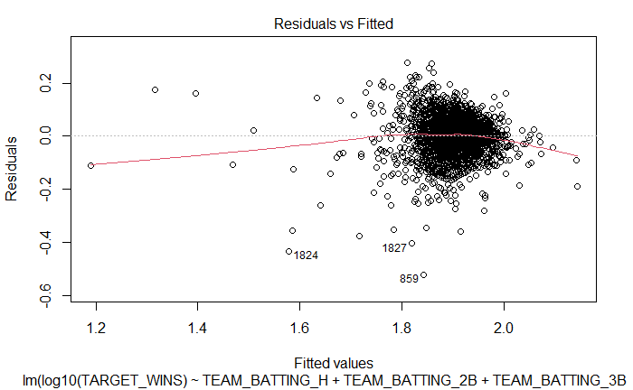

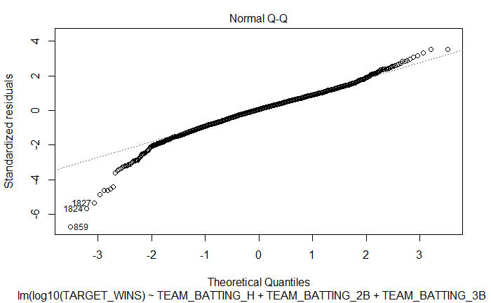

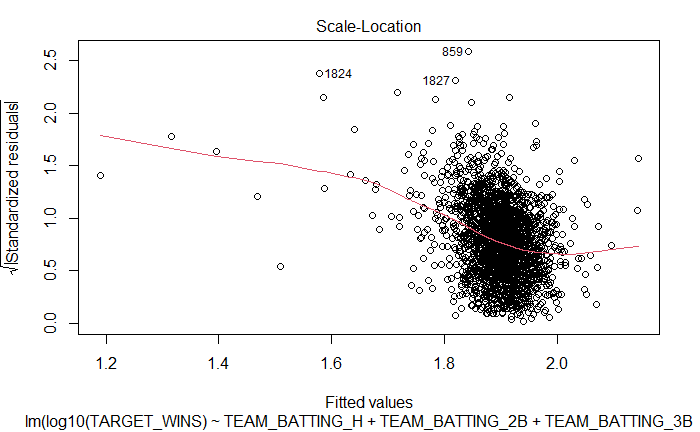

```r
plot(lr_md10)
```

[figure not shown]

```r
NA
```

```r
test <- read.csv("moneyball_test.csv")

head(test)
```

|  | X | INDEX | TEAM_BATTING_H | TEAM_BATTING_2B | TEAM_BATTING_3B | TEAM_BATTING_HR | TEAM_BATTING_BB | TEAM_BATTING_SO | TEAM_BASERUN_SB | TEAM_BASERUN_CS | TEAM_BATTING_HBP | TEAM_PITCHING_H | TEAM_PITCHING_HR | TEAM_PITCHING_BB | TEAM_PITCHING_SO | TEAM_FIELDING_E | TEAM_FIELDING_DP |
| --- | --- | --- | --- | --- | --- | --- | --- | --- | --- | --- | --- | --- | --- | --- | --- | --- | --- |
| 1 | 0 | 9 | 1209 | 170 | 33 | 83 | 447 | 1080 | 62 | 50 | NA | 1209 | 83 | 447 | 1080 | 140 | 156 |
| 2 | 1 | 10 | 1221 | 151 | 29 | 88 | 516 | 929 | 54 | 39 | NA | 1221 | 88 | 516 | 929 | 135 | 164 |
| 3 | 2 | 14 | 1395 | 183 | 29 | 93 | 509 | 816 | 59 | 47 | NA | 1395 | 93 | 509 | 816 | 156 | 153 |
| 4 | 3 | 47 | 1539 | 309 | 29 | 159 | 486 | 914 | 148 | 57 | 42 | 1539 | 159 | 486 | 914 | 124 | 154 |
| 5 | 4 | 60 | 1445 | 203 | 68 | 5 | 95 | 416 | NA | NA | NA | 3902 | 14 | 257 | 1123 | 616 | 130 |
| 6 | 5 | 63 | 1431 | 236 | 53 | 10 | 215 | 377 | NA | NA | NA | 2793 | 20 | 420 | 736 | 572 | 105 |

```r
dim(test)
```

```
[1] 259  17
```

```r
test = subset(test, select = -c(TEAM_BASERUN_CS, TEAM_BATTING_HBP, TEAM_FIELDING_DP) )

dim(test)
```

```
[1] 259  14
```

```r
names(which(colSums(is.na(test))>0))
```

```
[1] "TEAM_BATTING_SO"  "TEAM_BASERUN_SB"  "TEAM_PITCHING_SO"
```

```r
for(i in 1:ncol(test)) {
  test[ , i][is.na(test[ , i])] <- mean(test[ , i], na.rm=TRUE)
}

names(which(colSums(is.na(test))>0))
```

```
character(0)
```

Add trunc team batting fields

```r
test <- test %>% mutate(trunc_team_batting =
                     case_when(TEAM_BATTING_H < 1122 ~ '1122',
                               TEAM_BATTING_H >= 1122 & TEAM_BATTING_H <= 2333 ~ '1',
                               TEAM_BATTING_H > 2333 ~ '2333')
)

head(test)
```

|  | X | INDEX | TEAM_BATTING_H | TEAM_BATTING_2B | TEAM_BATTING_3B | TEAM_BATTING_HR | TEAM_BATTING_BB | TEAM_BATTING_SO | TEAM_BASERUN_SB | TEAM_PITCHING_H | TEAM_PITCHING_HR | TEAM_PITCHING_BB | TEAM_PITCHING_SO | TEAM_FIELDING_E | trunc_team_batting |
| --- | --- | --- | --- | --- | --- | --- | --- | --- | --- | --- | --- | --- | --- | --- | --- |
| 1 | 0 | 9 | 1209 | 170 | 33 | 83 | 447 | 1080 | 62.0000 | 1209 | 83 | 447 | 1080 | 140 | 1 |
| 2 | 1 | 10 | 1221 | 151 | 29 | 88 | 516 | 929 | 54.0000 | 1221 | 88 | 516 | 929 | 135 | 1 |
| 3 | 2 | 14 | 1395 | 183 | 29 | 93 | 509 | 816 | 59.0000 | 1395 | 93 | 509 | 816 | 156 | 1 |
| 4 | 3 | 47 | 1539 | 309 | 29 | 159 | 486 | 914 | 148.0000 | 1539 | 159 | 486 | 914 | 124 | 1 |
| 5 | 4 | 60 | 1445 | 203 | 68 | 5 | 95 | 416 | 123.7033 | 3902 | 14 | 257 | 1123 | 616 | 1 |
| 6 | 5 | 63 | 1431 | 236 | 53 | 10 | 215 | 377 | 123.7033 | 2793 | 20 | 420 | 736 | 572 | 1 |

```r
NA
NA
```

```r
test <- dummy_cols(test,
                   select_columns = "trunc_team_batting")

head(test)
```

|  | X | INDEX | TEAM_BATTING_H | TEAM_BATTING_2B | TEAM_BATTING_3B | TEAM_BATTING_HR | TEAM_BATTING_BB | TEAM_BATTING_SO | TEAM_BASERUN_SB | TEAM_PITCHING_H | TEAM_PITCHING_HR | TEAM_PITCHING_BB | TEAM_PITCHING_SO | TEAM_FIELDING_E | trunc_team_batting | trunc_team_batting_1 | trunc_team_batting_1122 |
| --- | --- | --- | --- | --- | --- | --- | --- | --- | --- | --- | --- | --- | --- | --- | --- | --- | --- |
| 1 | 0 | 9 | 1209 | 170 | 33 | 83 | 447 | 1080 | 62.0000 | 1209 | 83 | 447 | 1080 | 140 | 1 | 1 | 0 |
| 2 | 1 | 10 | 1221 | 151 | 29 | 88 | 516 | 929 | 54.0000 | 1221 | 88 | 516 | 929 | 135 | 1 | 1 | 0 |
| 3 | 2 | 14 | 1395 | 183 | 29 | 93 | 509 | 816 | 59.0000 | 1395 | 93 | 509 | 816 | 156 | 1 | 1 | 0 |
| 4 | 3 | 47 | 1539 | 309 | 29 | 159 | 486 | 914 | 148.0000 | 1539 | 159 | 486 | 914 | 124 | 1 | 1 | 0 |
| 5 | 4 | 60 | 1445 | 203 | 68 | 5 | 95 | 416 | 123.7033 | 3902 | 14 | 257 | 1123 | 616 | 1 | 1 | 0 |
| 6 | 5 | 63 | 1431 | 236 | 53 | 10 | 215 | 377 | 123.7033 | 2793 | 20 | 420 | 736 | 572 | 1 | 1 | 0 |

```r
max(test$TEAM_BATTING_H)
```

```
[1] 2170
```

There are no teams with batting hits above 2333, so the trunc_team_batting_2333 column was not generated.

```r
zeros <- as.list(rep(0,259))

test$trunc_team_batting_2333 <- 0

head(test)
```

|  | X | INDEX | TEAM_BATTING_H | TEAM_BATTING_2B | TEAM_BATTING_3B | TEAM_BATTING_HR | TEAM_BATTING_BB | TEAM_BATTING_SO | TEAM_BASERUN_SB | TEAM_PITCHING_H | TEAM_PITCHING_HR | TEAM_PITCHING_BB | TEAM_PITCHING_SO | TEAM_FIELDING_E | trunc_team_batting | trunc_team_batting_1 | trunc_team_batting_1122 | trunc_team_batting_2333 |
| --- | --- | --- | --- | --- | --- | --- | --- | --- | --- | --- | --- | --- | --- | --- | --- | --- | --- | --- |
| 1 | 0 | 9 | 1209 | 170 | 33 | 83 | 447 | 1080 | 62.0000 | 1209 | 83 | 447 | 1080 | 140 | 1 | 1 | 0 | 0 |
| 2 | 1 | 10 | 1221 | 151 | 29 | 88 | 516 | 929 | 54.0000 | 1221 | 88 | 516 | 929 | 135 | 1 | 1 | 0 | 0 |
| 3 | 2 | 14 | 1395 | 183 | 29 | 93 | 509 | 816 | 59.0000 | 1395 | 93 | 509 | 816 | 156 | 1 | 1 | 0 | 0 |
| 4 | 3 | 47 | 1539 | 309 | 29 | 159 | 486 | 914 | 148.0000 | 1539 | 159 | 486 | 914 | 124 | 1 | 1 | 0 | 0 |
| 5 | 4 | 60 | 1445 | 203 | 68 | 5 | 95 | 416 | 123.7033 | 3902 | 14 | 257 | 1123 | 616 | 1 | 1 | 0 | 0 |
| 6 | 5 | 63 | 1431 | 236 | 53 | 10 | 215 | 377 | 123.7033 | 2793 | 20 | 420 | 736 | 572 | 1 | 1 | 0 | 0 |

Submit first two models that have team_batting_hr in them:

```r
dim(test)
```

```
[1] 259  18
```

```r
test1 = subset(test, select = -c(trunc_team_batting, trunc_team_batting_1) )

dim(test1)
```

```
[1] 259  16
```

```r
head(test1)
```

|  | X | INDEX | TEAM_BATTING_H | TEAM_BATTING_2B | TEAM_BATTING_3B | TEAM_BATTING_HR | TEAM_BATTING_BB | TEAM_BATTING_SO | TEAM_BASERUN_SB | TEAM_PITCHING_H | TEAM_PITCHING_HR | TEAM_PITCHING_BB | TEAM_PITCHING_SO | TEAM_FIELDING_E | trunc_team_batting_1122 | trunc_team_batting_2333 |
| --- | --- | --- | --- | --- | --- | --- | --- | --- | --- | --- | --- | --- | --- | --- | --- | --- |
| 1 | 0 | 9 | 1209 | 170 | 33 | 83 | 447 | 1080 | 62.0000 | 1209 | 83 | 447 | 1080 | 140 | 0 | 0 |
| 2 | 1 | 10 | 1221 | 151 | 29 | 88 | 516 | 929 | 54.0000 | 1221 | 88 | 516 | 929 | 135 | 0 | 0 |
| 3 | 2 | 14 | 1395 | 183 | 29 | 93 | 509 | 816 | 59.0000 | 1395 | 93 | 509 | 816 | 156 | 0 | 0 |
| 4 | 3 | 47 | 1539 | 309 | 29 | 159 | 486 | 914 | 148.0000 | 1539 | 159 | 486 | 914 | 124 | 0 | 0 |
| 5 | 4 | 60 | 1445 | 203 | 68 | 5 | 95 | 416 | 123.7033 | 3902 | 14 | 257 | 1123 | 616 | 0 | 0 |
| 6 | 5 | 63 | 1431 | 236 | 53 | 10 | 215 | 377 | 123.7033 | 2793 | 20 | 420 | 736 | 572 | 0 | 0 |

```r
NA
```

Submit lr_md5

```r
preds <- predict(lr_md5, test1)

submit <- data_frame('Index' = test1$INDEX, 'P_TARGET_WINS' = preds)

write_csv(submit, 'submission2.csv')
```

Submit lr_md7, reverse log transformation

```r
preds <- exp(predict(lr_md7, test1))

submit <- data_frame('Index' = test1$INDEX, 'P_TARGET_WINS' = preds)

write_csv(submit, 'submission3.csv')
```

This performed worse than lr_md5, lets try lr_md6

```r
preds <- exp(predict(lr_md6, test1))

submit <- data_frame('Index' = test1$INDEX, 'P_TARGET_WINS' = preds)

write_csv(submit, 'submission4.csv')
```

This performed slightly worse than lr_md7

submit lr_md8:

```r
preds <- exp(predict(lr_md8, test1))

submit <- data_frame('Index' = test1$INDEX, 'P_TARGET_WINS' = preds)

write_csv(submit, 'submission5.csv')
```

Lets try lr_md10, which has a log10 transformation

```r
preds <- 10^(predict(lr_md10, test1))

submit <- data_frame('Index' = test1$INDEX, 'P_TARGET_WINS' = preds)

write_csv(submit, 'submission6.csv')
```

## Section 4, Formula for lr_md8

```r
#Return Model Equation

cc <- lr_md8$coefficients
(eqn <- paste("Y =", paste(round(cc[1],5), paste(round(cc[-1],5), names(cc[-1]), sep=" * ", collapse=" + "), sep=" + "), "+ e"))
```

[output not shown]

Compare equation to lr_md2, the model that had the best test performance

```r
#Return Model Equation

cc <- lr_md2$coefficients
(eqn <- paste("Y =", paste(round(cc[1],5), paste(round(cc[-1],5), names(cc[-1]), sep=" * ", collapse=" + "), sep=" + "), "+ e"))
```

[output not shown]

The only differences are the removal of TEAM_BATTING_HR, sqrt transforming some predictors, and the added trunc_team_batting fields.